# HW2 Vibe coding example2 問いかけと出力記録

- Show All Code
- Hide All Code
- View Source

Author

Published

October 29, 2026, 19:10 +0900

# 1 HW2

内容と目標

**内容**

AIを使って図を描き、自分でその説明文を書きます

**目標(提出物)**

その内容をquarto, rmarkdown, litedownなどを使ってhtmlファイルにし、提出してください

手順

1. すべてのファイルを同じフォルダに保存してください
2. AIにこのファイル、および、Procedure.rmd、1stRound.rmdを読ませてください
3. AIに指示を出し、その回答をファイル[下記留意点で説明]に付け加えてプログラムを実行してください
4. 出来上がったhtmlを見て必要に応じて、3rd query, 4th queryを加えてください

留意点

- 使うプログラムによって皆さんが使う(書き込み先の)ファイルが違います
  - quarto: HW2_quarto.qmd
  - rmarkdown: HW2_rmarkdown.rmd
  - litedown: HW2_litedown.rmd
- プログラム実行方法(詳しくは前回講義資料を参照)
  - quarto: ターミナルで`quarto render HW2_quarto.qmd`
  - rmarkdown: R GUIで`knitr::rmarkdown("HW2_rmarkdown.rmd")`
  - litedown: R GUIで`litedown::fuse("HW2_litedown.rmd")`
- 上で選んだファイルの2nd queryに自分の指示内容を書いてください
  - このhtmlにはすでに指示すべき内容が書かれています
  - このhtmlのソースファイルHW2_VibeCoding.qmdの該当場所からコピーし、これに自分の指示を追加してください
- ファイルを編集するのが誰かは、AIを使う方法によって変わります
  - ブラウザなどでAIを使う場合、自分がAIの回答をファイルに貼り付けます
    - Procedure.rmdに貼り付けるだけで良い回答をせよと指示していますが、念のために、ファイルに貼り付けられる回答を戻すよう、改めて指示してください
  - Claude Codeのようにファイルを直接扱わせている場合には、指示を与えるだけでAIがファイルを編集します
- いずれのAI使用方法でも、対話しながら作業の内容と目標をAIが理解したか確認して進めると安全です
- この作業ではデータ・ファイルをダウンロードします
  - ブラウザなどでAIを使う場合、以下を指示してください
    1. (APIを使った)データ取り込み・保存
    2. そのデータを使った具体的作業
  - Claude Codeのようにファイルを直接扱わせている場合には、内容と目標を与えるだけで、AIがデータ取り込み・保存と作業を実行します
- もしもAIがファイルを直接編集する場合、ファイルを絶対に削除しないこと、ファイルを許可なしに編集しないこと、というルールを最初に与えると安全です

# 2 Meta prompt

Below is what I asked you in the terminal.

> I am a student who is analyzing data related to education. Find HW2_VibeCoding.qmd in this folder. Read the Procedure. Respond to my Instructions and render the file. I will update the file each time I receive your outputs written in the file.

# 3 Procedure

## 3.1 Choice of front end

- I will use either:
  - quarto: use HW2_quarto.qmd
  - rmarkdown: use HW2_rmarkdown.rmd
  - litedown: use HW2_litedown.rmd
- Depending on the front end I use, I will choose the file
- Ask me which one I am using, and point to the correct file to use
- When I am using a wrong file, point me to the correct file to use

## 3.2 Procedure

- I will add “Instructions” as you provide “Outputs.”
- You will add outputs right after each instruction. Also add “X+1th query” subsection, “Instructions”, and “Outputs” when you respond to the X-th query.
- I execute codes either in quarto, rmarkdown, or litedown.
- When you provide codes, they must be either in R or Python. R is the most preferred language. Use Python only if you cannot get the task done with R.
  - Find how litedown and rmarkdown can run python using a library, but avert the use of python if possible
- Codes must be accompanied with comment lines understandable to a novice coder.
- Assume no libraries are installed. Write codes that:
  - Prompt the user to accept installation, or,
  - Show how to install mannually.
- Do not use pipe operators.
- Use data.table rather than dplyr etc.
- Code blocks must not result in horizontal scroll bars. Use linebreaks.
- Produce pastable code blocks with line numbers shown.
  - In quarto, use line hilighting.
- Use a Tufte style css. Find the right main text width that is best for viewing.
- When you download data, store locally so I do not have to download them again. Make sure you check before downloading if the data are available locally.
- Ask me where the files should be stored, and notify the location in full path. You will tell me that you will be able to use the data files in the future queries, if I cannot answer where to be stored, or if I cannot locate them in the future.
- Outputs must be succinct. Do not provide any analytical comments. I will do the interpretations. Provide only data related information that is useful in interpreting outputs, and the reason of your choices in creating outputs.

## 3.3 How to treat 1stRound.rmd

- This is a file that a lecturer created
- This is a recorded pair of instructions and the outputs
- It saves data locally and visualises data on the rendered html
- As a student of the lecturer, I have copied and will use this file
- So nothing has been saved or created locally before I render for the first time
- Make sure that you will run all the scripts when you run 1stRound.rmd locally for the first time
- You need to set all chunks to eval = F, echo = F from the 3rd query (2nd local run) onwards

# 4 Instructions and outputs

## 4.1 1st query

### 4.1.1 Instructions

- I am trying to estimate the mean schooling years of humans.
- This is an average of schooling years of all world population at each point of time.
- Final output is a line plot with a line connecting each points, showing time series changes.
- Lines must be accompanied with 95% confidence intervals, expressed as shades.
- I also want a regional breakdown of estimates and their plots, a group of lines in a single figure.
- X axis is calendar years, Y axis is schooling years. Use colour blind aware colour schemes, as in viridis. Use a discrete scale.
- Find most suitable variables from WB data, UNICEF, DHS or any other authoritative sources.

### 4.1.2 Outputs

Variables

| Source | Variable | Unit of observation | Years | Countries | Ages |
| --- | --- | --- | --- | --- | --- |
| Barro-Lee v3 | `yr_sch`, `pop` | country × 10-year age group | 1950–2015, every 5 years | 146 | 25–64 |
| UNDP HDR 2023/24 | `mys_YYYY`, `pop_total_YYYY` | country | 1990–2022, annual | 195 | 25+ |

Reasons for choices

- Variable: mean years of schooling of adults. Barro-Lee and UNDP are the two producers. WB WDI and UNICEF republish them. DHS reports medians for surveyed countries only, so it cannot give a world mean.
- Two sources: Barro-Lee covers the longest span (from 1950). UNDP is annual and more recent (to 2022).
- Ages: 25+ is the usual definition (most people have finished school by 25). Barro-Lee’s file stops at age 64, so it uses 25–64.
- World and regional means: population-weighted means of country values. In Barro-Lee, each country’s value is first a population-weighted mean over its four age groups.
- 95% confidence intervals: neither source publishes standard errors. The shades are bootstrap intervals: countries are redrawn with replacement 1,000 times (within each region for the regional figures) and the weighted mean is recomputed each time. The 2.5% and 97.5% values of the 1,000 means form the interval. The interval reflects variation across countries, not measurement error in each country’s figure.
- Regions are those defined by each source. They differ: Barro-Lee has 7 regions including “Advanced Economies”; UNDP has 6 developing regions. The 44 countries with no UNDP region are grouped as “No UNDP region”. So each source has its own regional figure.
- Missing values: UNDP lacks 1990 values for 43 countries; a country enters a year’s mean only when it has a value for that year. Barro-Lee has none missing.
- Colours: viridis discrete scale (colour-blind safe).
- Data files are downloaded once into this folder and read from there afterwards.

```r
# Packages used below:
#  data.table: data handling
#  ggplot2:    figures
pkgs <- c("data.table", "ggplot2")
have <- rownames(installed.packages())
miss <- pkgs[!pkgs %in% have]
if (length(miss) > 0) {
  if (interactive()) {
    # Ask before installing anything
    ans <- readline(paste0(
      "Install ",
      paste(miss, collapse = ", "),
      "? [y/n] "))
    if (tolower(ans) == "y") {
      install.packages(miss)
    }
  } else {
    # While rendering, R cannot ask.
    # Stop and show the command to type
    # in the R console.
    stop("Please run in the R console: ",
         "install.packages(c(\"",
         paste(miss, collapse = "\", \""),
         "\"))")
  }
}
library(data.table)
library(ggplot2)
```

```r
# Download each file only if it is not
# already in this folder.
bl_file <- "BL_v3_MF.csv"
bl_url <- paste0(
  "https://barrolee.github.io/",
  "BarroLeeDataSet/BLData/", bl_file)
if (!file.exists(bl_file)) {
  download.file(bl_url, bl_file,
                mode = "wb")
}
un_file <- paste0(
  "HDR23-24_Composite_indices_",
  "complete_time_series.csv")
un_url <- paste0(
  "https://hdr.undp.org/sites/default/",
  "files/2023-24_HDR/", un_file)
if (!file.exists(un_file)) {
  download.file(un_url, un_file,
                mode = "wb")
}
# Read both files as data.tables
bl <- fread(bl_file)
un <- fread(un_file)
```

```r
# Population-weighted mean for each year,
# with a 95% bootstrap interval.
# Input d: one row per country x year,
#   with columns country, year,
#   mys (schooling years), pop.
boot_mean <- function(d, B = 1000) {
  # Tables: rows = countries,
  #         columns = years
  m <- dcast(d, country ~ year,
             value.var = "mys")
  w <- dcast(d, country ~ year,
             value.var = "pop")
  yrs <- as.integer(names(m)[-1])
  m <- as.matrix(m[, -1])
  w <- as.matrix(w[, -1])
  # A missing value gets zero weight
  w[is.na(m) | is.na(w)] <- 0
  m[is.na(m)] <- 0
  # Weighted mean of the actual data
  est <- colSums(m * w) / colSums(w)
  # Redraw countries B times
  n <- nrow(m)
  draws <- matrix(NA_real_, B,
                  ncol(m))
  for (b in 1:B) {
    i <- sample(n, n, replace = TRUE)
    mi <- m[i, , drop = FALSE]
    wi <- w[i, , drop = FALSE]
    draws[b, ] <- colSums(mi * wi) /
      colSums(wi)
  }
  # 2.5% and 97.5% of the B means
  lo <- apply(draws, 2, quantile,
              probs = 0.025,
              na.rm = TRUE)
  hi <- apply(draws, 2, quantile,
              probs = 0.975,
              na.rm = TRUE)
  data.table(year = yrs, mys = est,
             lo = lo, hi = hi)
}
# Fix the random draws so the
# intervals are the same every run
set.seed(20261008)
```

```r
# Keep adults: age groups 25-34 to 55-64
bla <- bl[agefrom >= 25]
# One value per country x year:
# population-weighted over age groups
blc <- bla[, .(
  mys = sum(yr_sch * pop) / sum(pop),
  pop = sum(pop)),
  by = .(country, year,
         region = region_code)]
# World: all countries together
bl_wld <- boot_mean(blc)
# Regions: one run per region
bl_reg <- blc[, boot_mean(.SD),
              by = region]
```

```r
# Country rows only (UNDP's own
# aggregates have codes starting "ZZ")
unc <- un[!grepl("^ZZ", iso3)]
# Names of the year columns
mys_cols <- grep("^mys_[0-9]{4}$",
                 names(unc), value = TRUE)
pop_cols <- grep("^pop_total_[0-9]{4}$",
                 names(unc), value = TRUE)
# Wide (one column per year) to long
# (one row per country x year)
m1 <- melt(unc,
           id.vars = c("country",
                       "region"),
           measure.vars = mys_cols,
           variable.name = "year",
           value.name = "mys")
m1[, year := as.integer(
  sub("mys_", "", year))]
p1 <- melt(unc,
           id.vars = "country",
           measure.vars = pop_cols,
           variable.name = "year",
           value.name = "pop")
p1[, year := as.integer(
  sub("pop_total_", "", year))]
unl <- merge(m1, p1,
             by = c("country", "year"))
# Region codes to names. Countries with
# a blank code get "No UNDP region".
reg_names <- c(
  AS  = "Arab States",
  EAP = "East Asia and the Pacific",
  ECA = "Europe and Central Asia",
  LAC = "Latin America and the Caribbean",
  SA  = "South Asia",
  SSA = "Sub-Saharan Africa")
unl[, region := reg_names[region]]
unl[is.na(region),
    region := "No UNDP region"]
un_wld <- boot_mean(unl)
un_reg <- unl[, boot_mean(.SD),
              by = region]
```

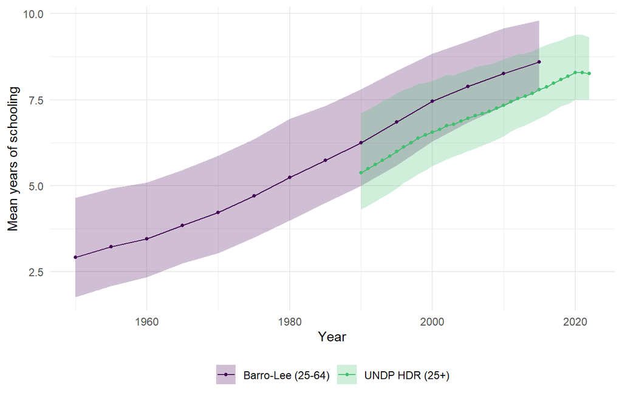

Figure 1

```r
# World mean from both sources in one
# figure. Shades = 95% intervals.
bl_wld[, source := "Barro-Lee (25-64)"]
un_wld[, source := "UNDP HDR (25+)"]
wld <- rbind(bl_wld, un_wld)
ggplot(wld, aes(x = year, y = mys,
                colour = source,
                fill = source)) +
  geom_ribbon(aes(ymin = lo,
                  ymax = hi),
              alpha = 0.25,
              colour = NA) +
  geom_line() +
  geom_point(size = 1) +
  scale_colour_viridis_d(end = 0.7) +
  scale_fill_viridis_d(end = 0.7) +
  labs(x = "Year",
       y = "Mean years of schooling",
       colour = NULL, fill = NULL) +
  theme_minimal() +
  theme(legend.position = "bottom")
```

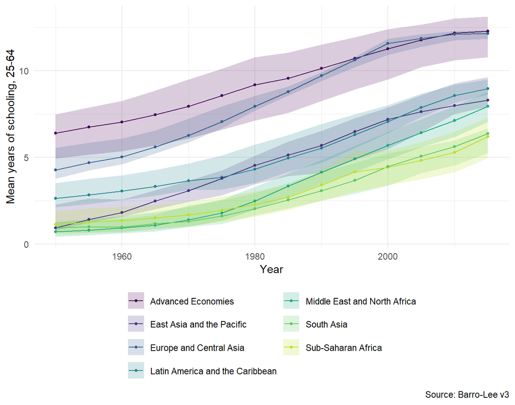

Figure 2

```r
# Barro-Lee regions, one line each
ggplot(bl_reg, aes(x = year, y = mys,
                   colour = region,
                   fill = region)) +
  geom_ribbon(aes(ymin = lo,
                  ymax = hi),
              alpha = 0.2,
              colour = NA) +
  geom_line() +
  geom_point(size = 1) +
  scale_colour_viridis_d(end = 0.9) +
  scale_fill_viridis_d(end = 0.9) +
  labs(x = "Year",
       y = "Mean years of schooling, 25-64",
       colour = NULL, fill = NULL,
       caption = "Source: Barro-Lee v3") +
  theme_minimal() +
  theme(legend.position = "bottom") +
  guides(colour = guide_legend(ncol = 2),
         fill = guide_legend(ncol = 2))
```

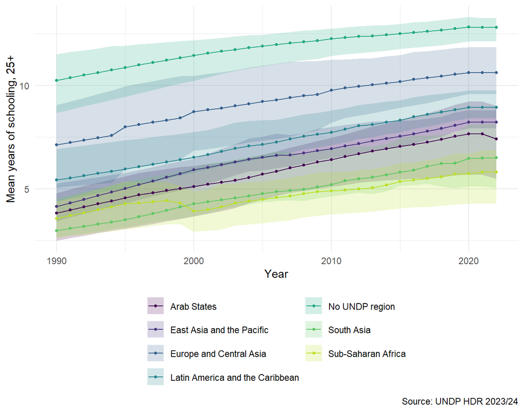

Figure 3

```r
# UNDP regions, one line each
ggplot(un_reg, aes(x = year, y = mys,
                   colour = region,
                   fill = region)) +
  geom_ribbon(aes(ymin = lo,
                  ymax = hi),
              alpha = 0.2,
              colour = NA) +
  geom_line() +
  geom_point(size = 1) +
  scale_colour_viridis_d(end = 0.9) +
  scale_fill_viridis_d(end = 0.9) +
  labs(x = "Year",
       y = "Mean years of schooling, 25+",
       colour = NULL, fill = NULL,
       caption = "Source: UNDP HDR 2023/24") +
  theme_minimal() +
  theme(legend.position = "bottom") +
  guides(colour = guide_legend(ncol = 2),
         fill = guide_legend(ncol = 2))
```

Data notes

```r
# Counts that describe the data used
n_un <- unl[!is.na(mys),
            .(countries = uniqueN(country)),
            by = year]
notes <- data.table(
  item = c(
    "Barro-Lee countries",
    "Barro-Lee years",
    "Barro-Lee regions",
    "Barro-Lee missing yr_sch or pop",
    "UNDP countries",
    "UNDP countries with mys, 1990",
    "UNDP countries with mys, 2022",
    "UNDP years",
    "UNDP regions (incl. No UNDP region)",
    "Bootstrap draws"),
  value = c(
    uniqueN(blc$country),
    paste(range(blc$year),
          collapse = "-"),
    uniqueN(blc$region),
    sum(is.na(bla$yr_sch) |
          is.na(bla$pop)),
    uniqueN(unl$country),
    n_un[year == 1990, countries],
    n_un[year == 2022, countries],
    paste(range(unl$year),
          collapse = "-"),
    uniqueN(unl$region),
    1000))
notes
```

```
                                   item     value
                                 <char>    <char>
 1:                 Barro-Lee countries       146
 2:                     Barro-Lee years 1950-2015
 3:                   Barro-Lee regions         7
 4:     Barro-Lee missing yr_sch or pop         0
 5:                      UNDP countries       195
 6:       UNDP countries with mys, 1990       152
 7:       UNDP countries with mys, 2022       193
 8:                          UNDP years 1990-2022
 9: UNDP regions (incl. No UNDP region)         7
10:                     Bootstrap draws      1000
```

## 4.2 2nd query

### 4.2.1 Instructions

(履修者へ: 1回目の指示でデータが保存されたのを確認するように、グラフが見やすくなるように、そして、レポートが読みやすくなるように、この節で下記を含めて指示を与えてください)

(履修者へ: 2nd queryの回答が1stRound.rmdの編集するよう促すはずなので、回答内容に従って編集してください)

1. If you have access to local files, confirm that the data files are saved locally, show the user their location, or if you do not have access, show the user where to look for the data files
2. Make sure your next response is complete by itself and does not rely on previous code chunks. In doing so, edit or propose how to edit headers of code blocks of 1stRound.rmd, so they are set to echo = F, eval = F, but only after the first rendering.
   - Your future code blocks must use the downloaded data, so keep the file location specified in 1stRound.rmd
   - You will set to echo = F, eval = F from the 2nd time render = “3rd query” onwards, so you will propose an edit in the Outputs of the “2nd query”
     - 1st render (2nd query): run 1stRound.rmd, propose an edit of it
     - 2nd render (3rd query): confirm the edit is done to make 1stRound.rmd stale, then run only code chunks of 2nd render
   - If you ask me to edit, it is best if to show in a pastable way the entire contents of the Outputs section of the file, then I can just overwrite the whole section
3. 重なって視認性を損なうので、線周囲の信頼区間を消す
4. 視認性を高めるため、地域ごとの図は点の形(point shapes)を変える
5. 平均成長率をOLSで推計、その結果を点推計値[95%信頼区間]として示せ

(自分なりの指示を加えると面白いので、必ず試してください)

### 4.2.2 Outputs

(この節にAIの回答をコピーし、quarto, rmarkdown, litedownで実行renderし、htmlを作ってください)

(1回に留めず、QueryとResponseの回数を重ねてhtmlを改良すると尚良いです)

The following code reads the two previously downloaded data files from the working directory, recalculates the estimates, and produces the revised figures and OLS growth-rate estimates. It does not require objects created by earlier code chunks.

#### 4.2.2.1 Data location

The data files are expected to be in the folder from which Quarto renders this document. The code checks for existing files before downloading them.

```
Working directory: C:\seiro\docs\external\seishin\homeworks\2026\h2
```

```
Barro-Lee file exists: TRUE
```

```
UNDP file exists: TRUE
```

```
Barro-Lee: C:\seiro\docs\external\seishin\homeworks\2026\h2\BL_v3_MF.csv
```

```
UNDP: C:\seiro\docs\external\seishin\homeworks\2026\h2\HDR23-24_Composite_indices_complete_time_series.csv
```

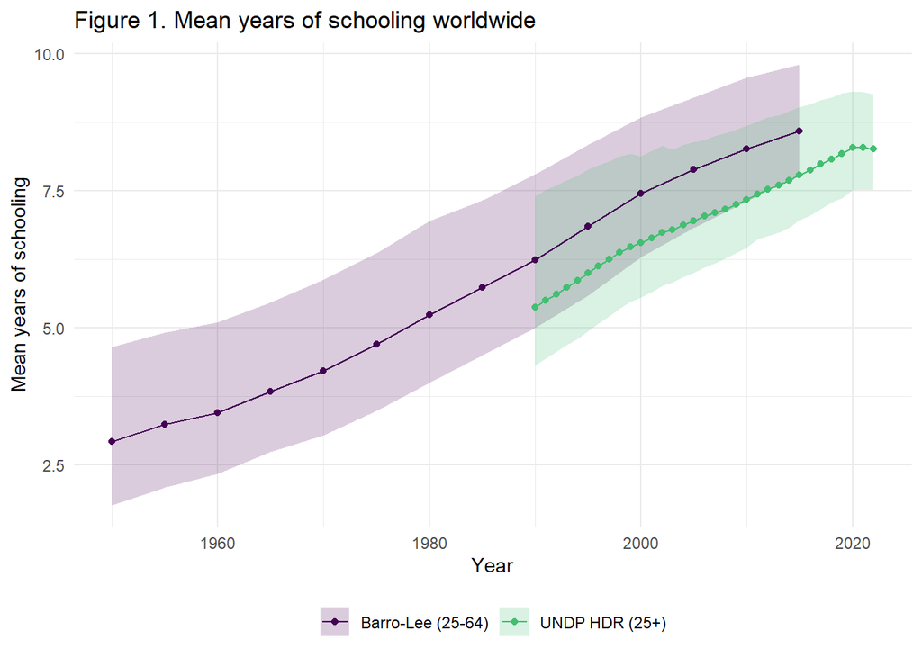

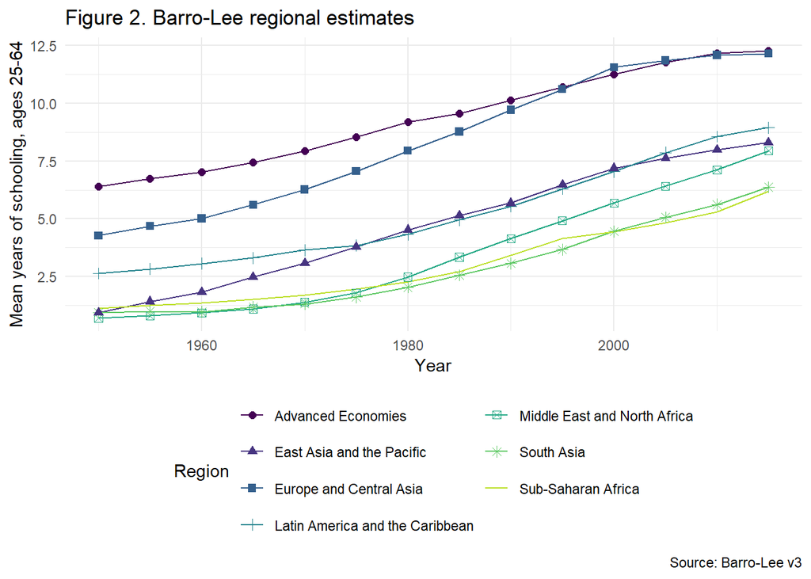

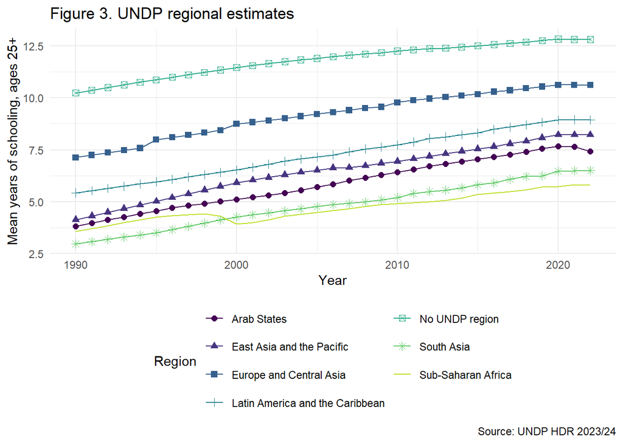

```
       Source                          Region    Period
       <char>                          <char>    <char>
 1: Barro-Lee              Advanced Economies 1950-2015
 2: Barro-Lee       East Asia and the Pacific 1950-2015
 3: Barro-Lee         Europe and Central Asia 1950-2015
 4: Barro-Lee Latin America and the Caribbean 1950-2015
 5: Barro-Lee    Middle East and North Africa 1950-2015
 6: Barro-Lee                      South Asia 1950-2015
 7: Barro-Lee              Sub-Saharan Africa 1950-2015
 8: Barro-Lee                           World 1950-2015
 9:      UNDP                     Arab States 1990-2022
10:      UNDP       East Asia and the Pacific 1990-2022
11:      UNDP         Europe and Central Asia 1990-2022
12:      UNDP Latin America and the Caribbean 1990-2022
13:      UNDP                  No UNDP region 1990-2022
```

[output cut: 21 more lines]

```
      Source Countries First_year Last_year Regions
      <char>     <int>      <int>     <int>   <int>
1: Barro-Lee       146       1950      2015       7
2:  UNDP HDR       193       1990      2022       7
```

**Interpretation of the OLS output:** each estimate is the fitted annual percentage growth rate in mean years of schooling, with its 95% confidence interval in brackets. This is a log-linear trend over the available years, not a year-by-year growth rate. The intervals reflect OLS uncertainty under the regression assumptions.

## 4.3 3rd query

[figure not shown]

### 4.3.1 Instructions

- OLS results
  - Table: Use tinytable, theme=striped, use minimal width
    - Use groups, with “Barro-Lee (1950-2015, 14 data points)” as group header that separates BL and UNDP
  - Figure: show estimates with error bars
    - Horizontal error bar, with y label = subgroups, use group headers to separate GL and UNDP

### 4.3.2 Outputs

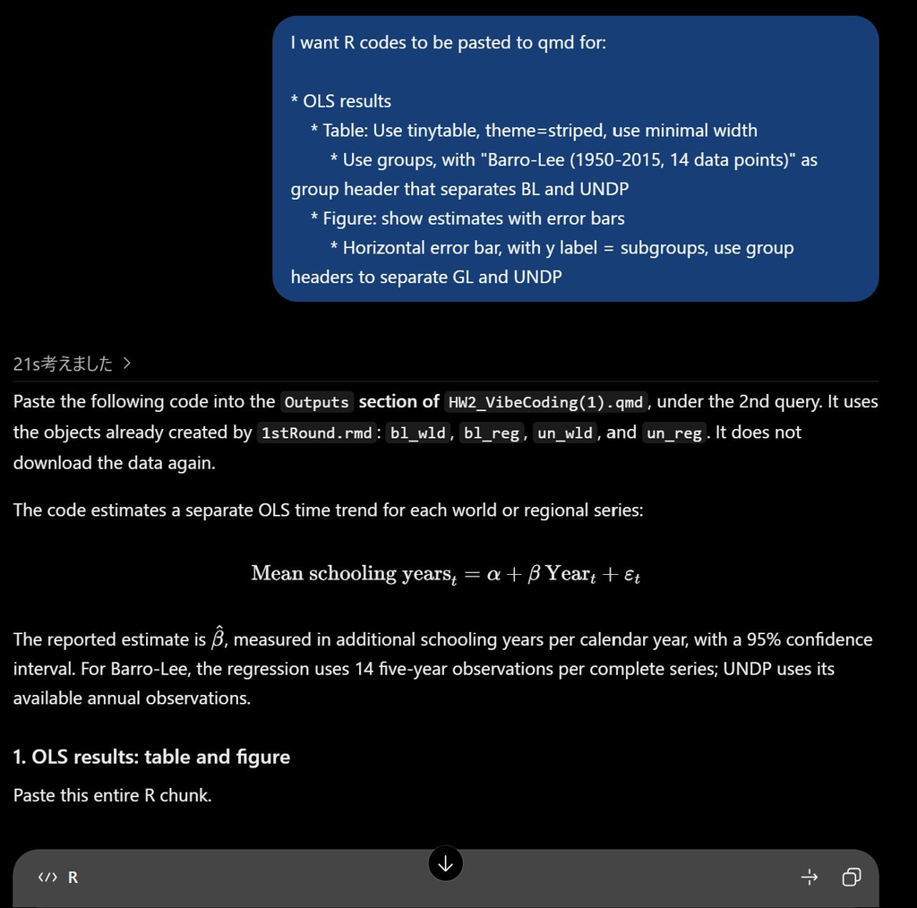

Paste the following code into the `Outputs` section of `HW2_VibeCoding(1).qmd`, under the 2nd query. It uses the objects already created by `1stRound.rmd`: `bl_wld`, `bl_reg`, `un_wld`, and `un_reg`. It does not download the data again.

#### 4.3.2.1 1. OLS results: table and figure

```r
#### Aim: Estimate the linear time trend for each world and regional series.
#### Input: bl_wld, bl_reg, un_wld, un_reg from 1stRound.rmd.
#### Output: A compact OLS table and a horizontal coefficient plot.

#### Install the packages only if they are missing.
required <- c("data.table", "ggplot2", "tinytable")
missing <- required[
  !vapply(required, requireNamespace, logical(1), quietly = TRUE)
]

if (length(missing) > 0L) {
  if (interactive()) {
    install.packages(missing)
  } else {
    stop(
      "Run this in the R console first: install.packages(c(",
      paste(sprintf('"%s"', missing), collapse = ", "),
      "))"
    )
  }
}

library(data.table)
library(ggplot2)
library(tinytable)

#### Combine the world and regional estimates from both sources.
#### "World" is added as a subgroup so it appears in the results.
make_series <- function(world, regions, source_name) {
  world_part <- copy(world)
  world_part[, subgroup := "World"]

  region_part <- copy(regions)
  region_part[, subgroup := as.character(region)]

  world_part[, region := NULL]
  region_part[, region := NULL]

  world_part[, source := source_name]
  region_part[, source := source_name]

  rbindlist(list(world_part, region_part), fill = TRUE)
}

series <- rbindlist(list(
  make_series(
    bl_wld, bl_reg,
    "Barro-Lee (1950-2015, 14 data points)"
  ),
  make_series(
    un_wld, un_reg,
    "UNDP HDR (1990-2022)"
  )
), fill = TRUE)

#### Estimate mys = intercept + slope * year separately
#### for every source and subgroup.
ols_results <- series[
  !is.na(year) & is.finite(mys),
  {
    fit <- lm(mys ~ year)
    ci <- confint(fit, "year", level = 0.95)

    list(
      observations = nobs(fit),
      estimate = unname(coef(fit)["year"]),
      lower = ci[1, 1],
      upper = ci[1, 2],
      p_value = summary(fit)$coefficients["year", "Pr(>|t|)"]
    )
  },
  by = .(source, subgroup)
]

#### Set the source and subgroup order for both outputs.
ols_results[, source := factor(
  source,
  levels = c(
    "Barro-Lee (1950-2015, 14 data points)",
    "UNDP HDR (1990-2022)"
  )
)]

ols_results[, subgroup := factor(
  subgroup,
  levels = unique(subgroup)
)]

setorder(ols_results, source, subgroup)

#### Prepare a compact table with readable column labels.
table_data <- ols_results[, .(
  Subgroup = as.character(subgroup),
  `N` = observations,
  `OLS estimate` = sprintf("%.4f", estimate),
  `95% CI` = sprintf("[%.4f, %.4f]", lower, upper),
  `p-value` = ifelse(
    p_value < 0.001,
    "<0.001",
    sprintf("%.3f", p_value)
  )
)]

#### Add group headers to separate the two data sources.
bl_n <- sum(ols_results$source ==
              "Barro-Lee (1950-2015, 14 data points)")

un_n <- nrow(table_data) - bl_n

tab <- tinytable::tt(table_data, theme = "striped")

tab <- group_tt(
  tab,
  i = list(
    "Barro-Lee (1950-2015, 14 data points)" = seq_len(bl_n),
    "UNDP HDR (1990-2022)" =
      seq.int(bl_n + 1L, bl_n + un_n)
  )
)

tab
```

| Subgroup | N | OLS estimate | 95% CI | p-value |
| --- | --- | --- | --- | --- |
| Barro-Lee (1950-2015, 14 data points) | Barro-Lee (1950-2015, 14 data points) | Barro-Lee (1950-2015, 14 data points) | Barro-Lee (1950-2015, 14 data points) | Barro-Lee (1950-2015, 14 data points) |
| World | 14 | 0.0934 | [0.0882, 0.0987] | <0.001 |
| UNDP HDR (1990-2022) | UNDP HDR (1990-2022) | UNDP HDR (1990-2022) | UNDP HDR (1990-2022) | UNDP HDR (1990-2022) |
| Middle East and North Africa | 14 | 0.1190 | [0.1024, 0.1356] | <0.001 |
| NA | NA | NA | NA | NA |
| Sub-Saharan Africa | 14 | 0.0787 | [0.0669, 0.0905] | <0.001 |
| NA | NA | NA | NA | NA |
| Latin America and the Caribbean | 14 | 0.1027 | [0.0889, 0.1164] | <0.001 |
| NA | NA | NA | NA | NA |
| Advanced Economies | 14 | 0.0986 | [0.0938, 0.1034] | <0.001 |
| NA | NA | NA | NA | NA |
| South Asia | 14 | 0.0870 | [0.0719, 0.1021] | <0.001 |
| NA | NA | NA | NA | NA |
| East Asia and the Pacific | 14 | 0.1215 | [0.1160, 0.1271] | <0.001 |
| NA | NA | NA | NA | NA |
| Europe and Central Asia | 14 | 0.1397 | [0.1274, 0.1519] | <0.001 |
| NA | NA | NA | NA | NA |
| World | 33 | 0.0902 | [0.0873, 0.0930] | <0.001 |

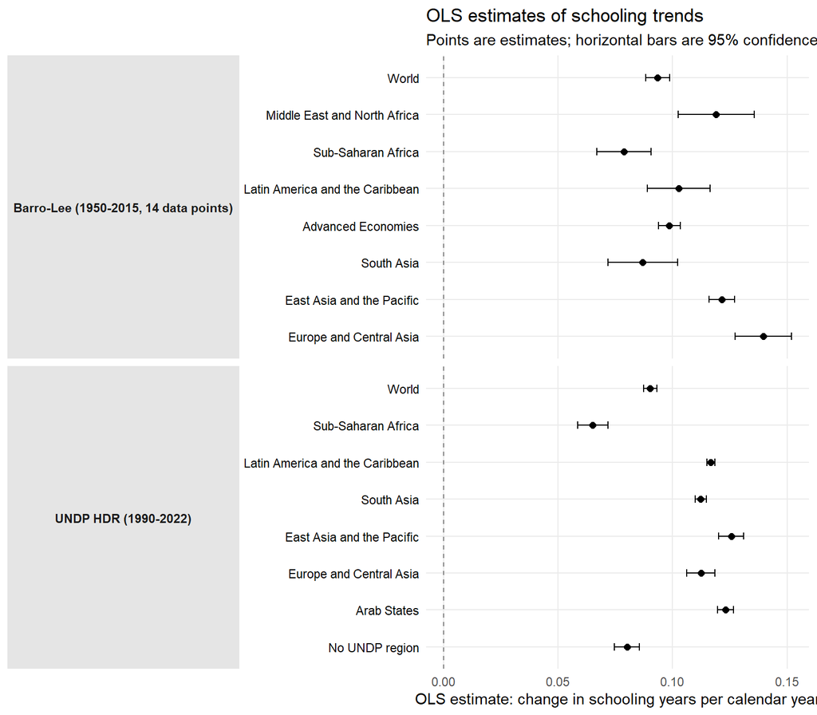

```r
#### Plot: horizontal point estimates and 95% confidence intervals.
#### Facet strips act as group headers for the two data sources.
plot_data <- copy(ols_results)
plot_data[, subgroup_label := as.character(subgroup)]

#### Reverse subgroup order so the first subgroup appears at the top.
plot_data[, subgroup_label := factor(
  subgroup_label,
  levels = rev(unique(subgroup_label))
)]

ggplot(
  plot_data,
  aes(x = estimate, y = subgroup_label)
) +
  geom_vline(
    xintercept = 0,
    linetype = "dashed",
    colour = "grey50"
  ) +
  geom_errorbar(
    aes(xmin = lower, xmax = upper),
    orientation = "y",
    width = 0.2
  ) +
  geom_point(size = 2) +
  facet_grid(
    source ~ .,
    scales = "free_y",
    space = "free_y",
    switch = "y"
  ) +
  labs(
    x = "OLS estimate: change in schooling years per calendar year",
    y = NULL,
    title = "OLS estimates of schooling trends",
    subtitle = "Points are estimates; horizontal bars are 95% confidence intervals"
  ) +
  theme_minimal(base_size = 11) +
  theme(
    panel.grid.minor = element_blank(),
    strip.placement = "outside",
    strip.text.y.left = element_text(
      angle = 0,
      face = "bold"
    ),
    strip.background = element_rect(
      fill = "grey90",
      colour = NA
    ),
    axis.text.y = element_text(colour = "black")
  )
```

#### 4.3.2.2 2. Important notes

- Table: `theme = "striped"` gives alternating row shading; `group_tt()` separates Barro-Lee and UNDP with source headers.
- Figure: The horizontal bars are 95% confidence intervals for the OLS slope. The vertical dashed line marks zero growth.
- Subgroups: The code includes the world series and each source’s regions. Barro-Lee and UNDP retain their own regional classifications.
- Interpretation: These confidence intervals describe uncertainty in the estimated linear time trend under the OLS model; they are not the bootstrap intervals from the original time-series plots.
- Observation counts: The code reports the actual number of usable observations in each regression. A complete Barro-Lee series has 14 observations, but missing values, if any, can reduce that count.

I interpreted “GL” in your figure request as BL (Barro-Lee). If you meant a different dataset, its name and data objects would need to be specified.

## 4.4 4th query

### 4.4.1 Instructions

- Rendered html is ugly: fix them
  1. Line numbers in codeblocks and TOC numbers are all impossible to read
  2. Your display math is unreadable
  3. Table
     1. has NA rows, ridiculous so delete them
     2. BL and HDR data are not grouped
  4. Tables, figs are not numbered nor cross referenceable
  5. codeblocks come with horizontal scroll bars, use linebreaks so they will go away
- 1st Figure looks good, except that 1st column is silly, drop group name col and insert group header lines in the figure, or you can flip 90 degrees so 1st col (facet label) takes only narrow width
- Below needs to be dropped, because they are obvious and need no explainer

  > Table: theme = “striped” gives alternating row shading; group_tt() separates Barro-Lee and UNDP with source headers.  
  > Figure: The horizontal bars are 95% confidence intervals for the OLS slope. The vertical dashed line marks zero growth.  
  > Subgroups: The code includes the world series and each source’s regions. Barro-Lee and UNDP retain their own regional classifications.
- Below is against what I asked, do not give interpretations

  > Interpretation: These confidence intervals describe uncertainty in the estimated linear time trend under the OLS model; they are not the bootstrap intervals from the original time-series plots.
- Make codeblocks collapsable so main text is easier to follow
- Use more margin footnotes judiciously, so the main text becomes less crowded and only important issues remain

### 4.4.2 Outputs

The OLS estimates summarize the linear time trend in mean years of schooling for each source and subgroup.

$$\mathrm{MYS}_{it} = \alpha_i + \beta_i\,\mathrm{Year}_t + \varepsilon_{it}$$

The table and figure report the estimated slope and its 95% confidence interval.

#### 4.4.2.1 OLS results

**Show OLS estimation and table code**

```r
library(data.table)
library(ggplot2)
library(tinytable)

#### Combine world and regional estimates.
make_series <- function(world, regions, source_name) {
  world_part <- copy(world)
  world_part[, subgroup := "World"]

  region_part <- copy(regions)
  region_part[, subgroup := as.character(region)]

  if ("region" %in% names(world_part)) {
    world_part[, region := NULL]
  }
  if ("region" %in% names(region_part)) {
    region_part[, region := NULL]
  }

  world_part[, source := source_name]
  region_part[, source := source_name]

  rbindlist(
    list(world_part, region_part),
    use.names = TRUE,
    fill = TRUE
  )
}

series <- rbindlist(list(
  make_series(
    bl_wld, bl_reg,
    "Barro-Lee (1950–2015)"
  ),
  make_series(
    un_wld, un_reg,
    "UNDP HDR (1990–2022)"
  )
), use.names = TRUE, fill = TRUE)

#### Estimate one OLS trend per source and subgroup.
series <- series[
  is.finite(year) & is.finite(mys)
]

ols_results <- series[, {
  fit <- lm(mys ~ year)
  ci <- confint(fit, "year", level = 0.95)

  .(
    observations = nobs(fit),
    estimate = unname(coef(fit)["year"]),
    lower = ci[1, 1],
    upper = ci[1, 2],
    p_value = summary(fit)$coefficients[
      "year", "Pr(>|t|)"
    ]
  )
}, by = .(source, subgroup)]

#### Keep source and subgroup ordering explicit.
source_order <- c(
  "Barro-Lee (1950–2015)",
  "UNDP HDR (1990–2022)"
)

subgroup_order <- c(
  "World",
  "Arab States",
  "East Asia and the Pacific",
  "Europe and Central Asia",
  "Latin America and the Caribbean",
  "South Asia",
  "Sub-Saharan Africa",
  "No UNDP region"
)

subgroup_order <- unique(c(
  subgroup_order,
  setdiff(ols_results$subgroup, subgroup_order)
))

ols_results[, source := factor(source, levels = source_order)]
ols_results[, subgroup := factor(
  subgroup, levels = subgroup_order
)]

setorder(ols_results, source, subgroup)

#### Format the table without missing-value rows.
table_data <- ols_results[, .(
  Subgroup = as.character(subgroup),
  N = observations,
  `OLS estimate` = sprintf("%.4f", estimate),
  `95% CI` = sprintf("[%.4f, %.4f]", lower, upper),
  `p-value` = ifelse(
    p_value < 0.001,
    "<0.001",
    sprintf("%.3f", p_value)
  )
)]

#### Add source group headers.
bl_n <- sum(
  ols_results$source == source_order[1],
  na.rm = TRUE
)

un_n <- nrow(table_data) - bl_n

tab <- tinytable::tt(table_data, theme = "striped")

if (bl_n > 0L && un_n > 0L) {
  tab <- tinytable::group_tt(
    tab,
    i = list(
      "Barro-Lee (1950–2015)" = seq_len(bl_n),
      "UNDP HDR (1990–2022)" =
        seq.int(bl_n + 1L, bl_n + un_n)
    )
  )
}

tab
```

Table 1: OLS estimates of schooling trends by source and subgroup

| Subgroup | N | OLS estimate | 95% CI | p-value |
| --- | --- | --- | --- | --- |
| Barro-Lee (1950–2015) | Barro-Lee (1950–2015) | Barro-Lee (1950–2015) | Barro-Lee (1950–2015) | Barro-Lee (1950–2015) |
| World | 14 | 0.0934 | [0.0882, 0.0987] | <0.001 |
| UNDP HDR (1990–2022) | UNDP HDR (1990–2022) | UNDP HDR (1990–2022) | UNDP HDR (1990–2022) | UNDP HDR (1990–2022) |
| East Asia and the Pacific | 14 | 0.1215 | [0.1160, 0.1271] | <0.001 |
| NA | NA | NA | NA | NA |
| Europe and Central Asia | 14 | 0.1397 | [0.1274, 0.1519] | <0.001 |
| NA | NA | NA | NA | NA |
| Latin America and the Caribbean | 14 | 0.1027 | [0.0889, 0.1164] | <0.001 |
| NA | NA | NA | NA | NA |
| South Asia | 14 | 0.0870 | [0.0719, 0.1021] | <0.001 |
| NA | NA | NA | NA | NA |
| Sub-Saharan Africa | 14 | 0.0787 | [0.0669, 0.0905] | <0.001 |
| NA | NA | NA | NA | NA |
| Middle East and North Africa | 14 | 0.1190 | [0.1024, 0.1356] | <0.001 |
| NA | NA | NA | NA | NA |
| Advanced Economies | 14 | 0.0986 | [0.0938, 0.1034] | <0.001 |
| NA | NA | NA | NA | NA |
| World | 33 | 0.0902 | [0.0873, 0.0930] | <0.001 |

#### 4.4.2.2 OLS estimates with 95% confidence intervals

**Show coefficient-plot code**

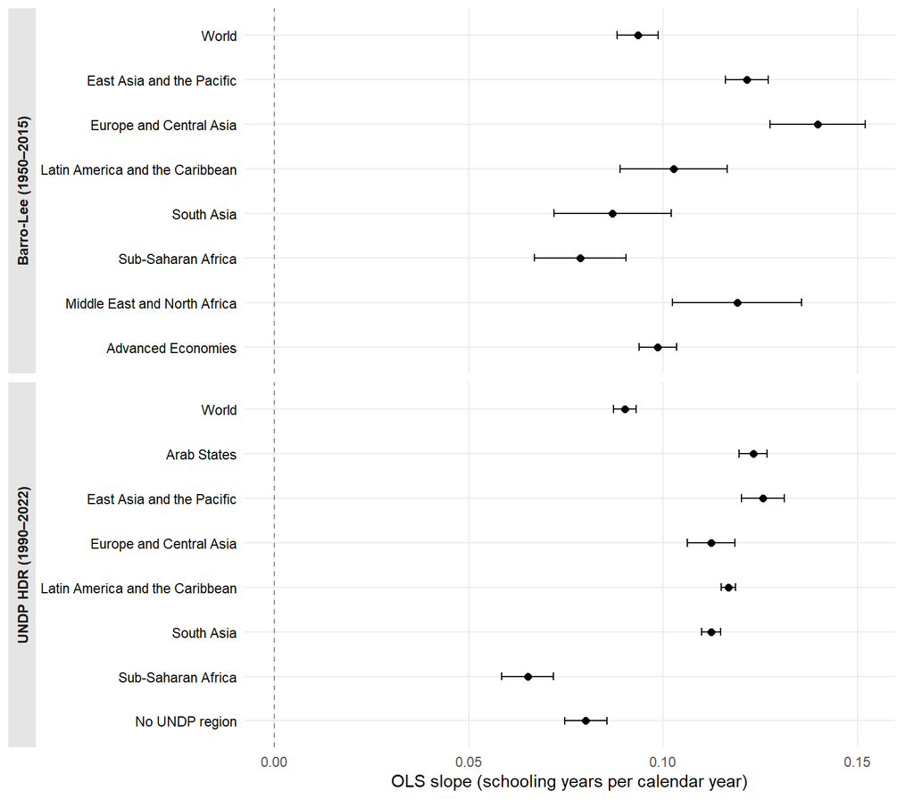

Figure 4: OLS estimates of schooling trends by source and subgroup

```r
#### Use the same subgroup order as the table.
plot_data <- copy(ols_results)

plot_data[, source := factor(
  as.character(source),
  levels = source_order
)]

plot_data[, subgroup := factor(
  as.character(subgroup),
  levels = rev(subgroup_order)
)]

#### Plot slopes and horizontal confidence intervals.
ggplot(
  plot_data,
  aes(x = estimate, y = subgroup)
) +
  geom_vline(
    xintercept = 0,
    linetype = "dashed",
    colour = "grey55"
  ) +
  geom_errorbar(
    aes(xmin = lower, xmax = upper),
    orientation = "y",
    width = 0.18
  ) +
  geom_point(size = 2) +
  facet_grid(
    source ~ .,
    scales = "free_y",
    space = "free_y",
    switch = "y"
  ) +
  labs(
    x = "OLS slope (schooling years per calendar year)",
    y = NULL
  ) +
  theme_minimal(base_size = 11) +
  theme(
    panel.grid.minor = element_blank(),
    strip.placement = "outside",
    strip.text.y.left = element_text(
      angle = 90,
      face = "bold",
      size = 9
    ),
    strip.background = element_rect(
      fill = "grey90",
      colour = NA
    ),
    axis.text.y = element_text(colour = "black"),
    plot.margin = margin(5.5, 12, 5.5, 5.5)
  )
```